# Migration ecology of a re-established trumpeter swan population

David W. Wolfson, Randall T. Knapik, Anna Buckardt Thomas, Laura J. Kearns, Brian W. Kiss, Taylor A. Finger, Tyler M. Harms, Sumner W. Matteson, Tiffany Mayo, Timothy F. Poole, John J. Moriarty, Margaret Smith, Christine M. Herwig, Drew N. Fowler, David E. Andersen, John R. Fieberg

## Supplemental Methods Description

Rule-based thresholds chosen:  
- Minimum distance between 2 potential segments: **2 kilometers**  
- Minimum time difference between 2 potential change points: **2 days**  
- Minimum distance moved between breeding/capture location and the furthest segment in order to consider onset of fall migration: **100 kilometers**  
- Minimum distance moved between the furthest segment and the segment representing return to spring territory: **100 kilometers**  
- Maximum distance between the spring return segment and the breeding/capture territory in order to consider a spring migration arrival: **30 kilometers**  
- Latest date to be considered a autumn departure / earliest date to be considered a spring return onset: **30 December**

## Supplemental Figures

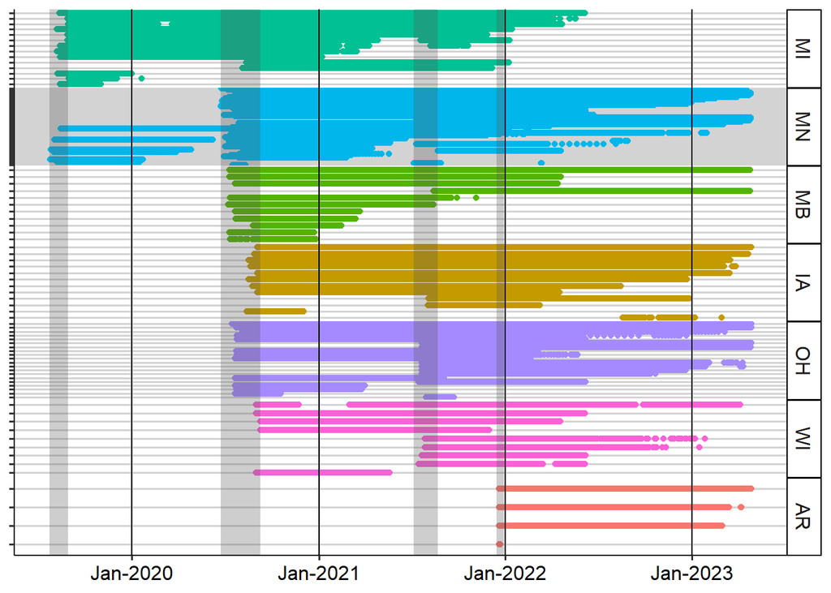

Figure S1. An overview of GPS telemetry data received from all collared IP trumpeter swans. Each line represents the period of data collection from a single collared swan. The grey regions indicate periods of collar deployment. The black lines are 1 January of each year. Number of deployments (including redeployments) by state/province are: Michigan (n=14), Minnesota (n=56), Manitoba (n=11), Iowa (n=12), Ohio (n=20), Wisconsin (n=9), and Arkansas (n=4).

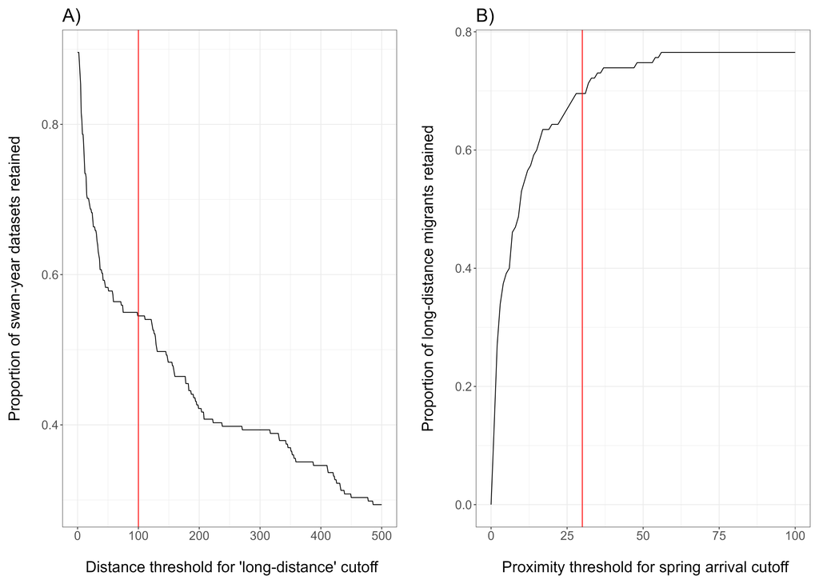

Figure S2. Sensitivity analyses for the distance thresholds used as cutoffs in estimation of migration categories. (A) The proportion of swan-year datasets that satisfy distance threshold cutoffs (0-500 km) for being considered a ‘long-distance’ migrant, and estimating an autumn departure date. The red line indicates the threshold of 100 km used in the analysis. (B) The proportion of swan-year datasets that satisfy a proximity threshold cutoff (0-100 km), defined as the minimum proximity to the previous year’s breeding/capture territory, used to estimate a spring arrival date. The red line indicates the threshold of 30 km used in the analysis.

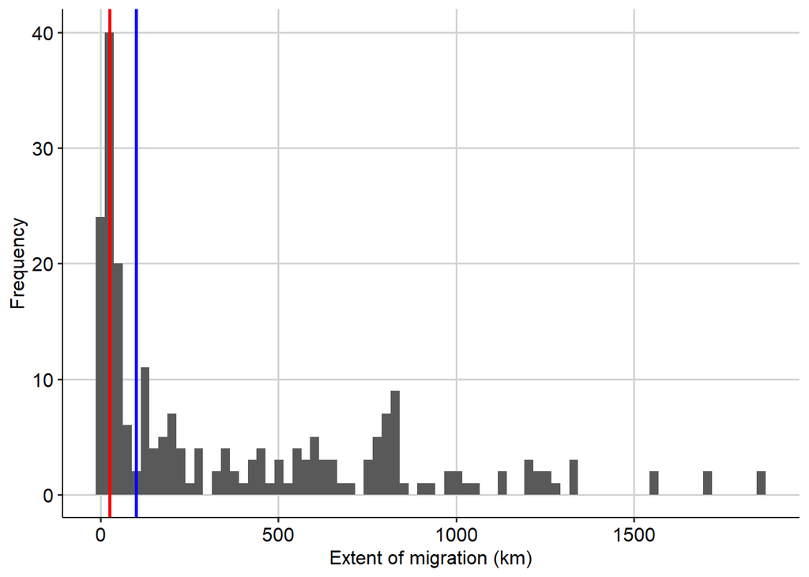

Figure S3. Histogram of the maximum annual distance moved from the breeding/capture territory for all 221 swan-year datasets. The distance thresholds used to define categories of movement (0-25 km, 25-100 km, >100 km) are shown with the red (25 km) and blue (100 km) lines.

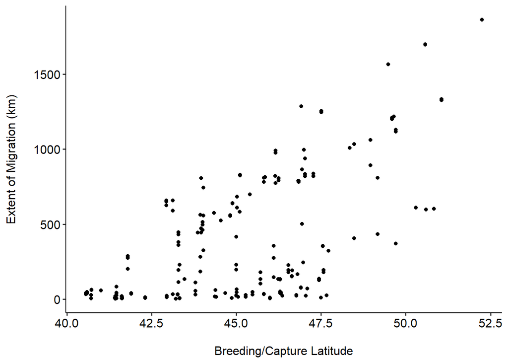

Figure S4. Breeding/capture latitude versus extent of migration (furthest distance from breeding territory during the nonbreeding season) for 221 ‘swan-year’ datasets representing annual migration cycles.

## Migration Phenology Summary Statistics:

### Autumn Departure

We estimated autumn departure dates for all swans that traveled >100km from the breeding/capture territory by 30 December.

Table S1. Compiled migration phenology of all autumn departures from 2019-2022.

| Total Swans Tracked | Number of Long-Distance Migrants | Number of Fall Departure Events | Average Fall Departure | Standard Deviation (days) | Earliest Departure | Latest Departure |
| --- | --- | --- | --- | --- | --- | --- |
| 122 | 71 | 117 | November 07 | 25 | September 01 | December 24 |

Table S2. Yearly summaries of migration phenology of autumn departures from 2019-2022.

| Year | Total Swans Tracked | Number of Long-Distance Migrants | Average Autumn Departure | Standard Deviation (days) | Earliest Departure | Latest Departure |
| --- | --- | --- | --- | --- | --- | --- |
| 2019 | 17 | 7 | October 31 | 7 | October 21 | November 08 |
| 2020 | 82 | 49 | November 02 | 28 | September 01 | December 24 |
| 2021 | 86 | 38 | November 09 | 24 | September 15 | December 23 |
| 2022 | 44 | 23 | November 17 | 18 | October 07 | December 20 |

Table S3. Autumn departure dates of long-distance migrants by breeding status

| Breeding Status | Total Swans Tracked | Number of Long-Distance Migrants | Number of Autumn Departure Events | Average Autumn Departure | Standard Deviation (days) | Earliest Departure | Latest Departure |
| --- | --- | --- | --- | --- | --- | --- | --- |
| Breeder | 70 | 36 | 68 | November 13 | 23 | September 15 | December 24 |
| Non-Breeder | 22 | 12 | 19 | October 22 | 27 | September 01 | November 29 |
| Paired | 21 | 14 | 19 | November 04 | 26 | September 27 | December 24 |

### Spring Arrival

We estimated spring arrival for all swans that traveled >100km from the breeding/capture territory during the non-breeding season, left their territory by 30 December, and returned to within <30 km of their previous year’s territory.

Table S4. Compiled migration phenology of all spring arrivals from 2020-2023.

| Total Swans Tracked | Number of Long-Distance Migrants | Number of Spring Arrival Events | Average Spring Arrival | Standard Deviation (days) | Earliest Arrival | Latest Arrival |
| --- | --- | --- | --- | --- | --- | --- |
| 122 | 51 | 84 | March 04 | 15 | January 18 | April 11 |

Table S5. Yearly summaries of migration phenology of spring arrivals from 2020-2023.

| Year | Total Swans Tracked | Number of Long-Distance Migrants | Average Spring Arrival | Standard Deviation (days) | Earliest Arrival | Latest Arrival |
| --- | --- | --- | --- | --- | --- | --- |
| 2020 | 17 | 4 | March 02 | 18 | February 08 | March 23 |
| 2021 | 82 | 35 | March 03 | 8 | January 31 | March 23 |
| 2022 | 86 | 33 | March 06 | 19 | January 18 | April 11 |
| 2023 | 44 | 12 | March 02 | 20 | February 06 | April 08 |

Table S6. Spring arrivals of long-distance migrants by breeding status

| Breeding Status | Total Swans Tracked | Number of Long-Distance Migrants | Number of Spring Arrival Events | Average Spring Arrival | Standard Deviation (days) | Earliest Arrival | Latest Arrival |
| --- | --- | --- | --- | --- | --- | --- | --- |
| Breeder | 70 | 29 | 54 | February 29 | 15 | January 18 | April 05 |
| Non-Breeder | 22 | 8 | 10 | March 12 | 9 | February 29 | March 27 |
| Paired | 21 | 8 | 11 | March 06 | 7 | March 01 | March 22 |

### Duration of nonbreeding season

We estimated duration of nonbreeding season for all swans that had an autumn departure (i.e., traveled >100 km from territory) followed by a spring arrival the following year. This migration metric represents the span of time absent from the breeding/capture territory during the nonbreeding season, and is calculated by the difference in days between spring arrival and the previous year’s autumn departure.

Table S7. Compiled duration of nonbreeding season for all swans from 2019-2023.

| Total Swans Tracked | Number of Long-Distance Migrants | Number of Annual Cycles | Average Duration of Nonbreeding Season (days) | Standard Deviation (days) |
| --- | --- | --- | --- | --- |
| 122 | 49 | 78 | 115 | 29 |

Table S8. Yearly summaries of duration of nonbreeding season from 2019-2020 until 2022-2023.

| Year | Total Swans Tracked | Number of Long-Distance Migrants | Average Duration of Nonbreeding Season (days) | Standard Deviation (days) |
| --- | --- | --- | --- | --- |
| 2020 | 17 | 4 | 119 | 21 |
| 2021 | 82 | 34 | 118 | 29 |
| 2022 | 86 | 28 | 117 | 28 |
| 2023 | 44 | 12 | 99 | 33 |

Table S9. Summaries by breeding status of duration of nonbreeding season from 2019-2020 until 2022-2023.

| Breeding Status | Total Swans Tracked | Number of Long-Distance Migrants | Average Duration of Nonbreeding Season (days) | Standard Deviation (days) |
| --- | --- | --- | --- | --- |
| Breeder | 70 | 29 | 109 | 29 |
| Non-Breeder | 22 | 8 | 133 | 28 |
| Paired | 21 | 8 | 126 | 23 |